# Butzke_HW7

Alden Butzke

4/11/2022

```r
getwd()
```

```
## [1] "/Users/aldenbutzke/Desktop/Datamining"
```

```r
setwd("/users/aldenbutzke/Desktop/Datamining/")
getwd()
```

```
## [1] "/Users/aldenbutzke/Desktop/Datamining"
```

```r
rm(list=ls())

library(tidyverse)
library(readxl)

Df<-read_xlsx("HWK6 Data.xlsx", sheet = "Wage")

Df.h<-head(Df, 5)

Df.h
```

```
## # A tibble: 5 × 5
##    Wage  Educ Exper   Age  Male
##   <dbl> <dbl> <dbl> <dbl> <dbl>
## 1  37.8    11     2    40     1
## 2  21.7     4     1    39     0
## 3  14.3     4     2    38     0
## 4  21.3     5     9    53     1
## 5  24.6     6    15    59     1
```

## First Model Equation

$\hat{Y}= \beta_0 + \beta_i + \beta_2 + \beta_n + \epsilon$

$\hat{Wage}= \beta_0 + \beta_1Educ + \beta_2Expert + \beta_3Age + \beta_4Male + \epsilon$

```r
lm1<-lm(data = Df, Wage~Educ+Exper+Age+Male)
lm1s<-summary(lm1)
lm1s
```

```
##
## Call:
## lm(formula = Wage ~ Educ + Exper + Age + Male, data = Df)
##
## Residuals:
##     Min      1Q  Median      3Q     Max
## -9.3233 -3.0944 -0.6868  2.4494 15.1348
##
## Coefficients:
##             Estimate Std. Error t value Pr(>|t|)
## (Intercept)  8.68476    4.09264   2.122  0.03937 *
## Educ         1.23273    0.36733   3.356  0.00162 **
## Exper        0.41659    0.14245   2.924  0.00539 **
## Age         -0.01900    0.08284  -0.229  0.81961
## Male         2.28966    1.67623   1.366  0.17874
## ---
## Signif. codes:  0 '***' 0.001 '**' 0.01 '*' 0.05 '.' 0.1 ' ' 1
##
## Residual standard error: 5.362 on 45 degrees of freedom
## Multiple R-squared:  0.3686, Adjusted R-squared:  0.3124
## F-statistic: 6.566 on 4 and 45 DF,  p-value: 0.000299
```

```r
clm1<-coefficients(lm1)
```

The First model is:  
$\hat{Wage}=$ 8.6847608 + $\beta_1 *$ 1.2327341 + $\beta_2 *$ 0.4165866 + $\beta_3 *$ -0.0190012 + $\beta_4 *$ 2.2896608 + $\epsilon$  
with an $\bar{R^2}$ value of 0.312422 and an $R^2$ of 0.3685508.

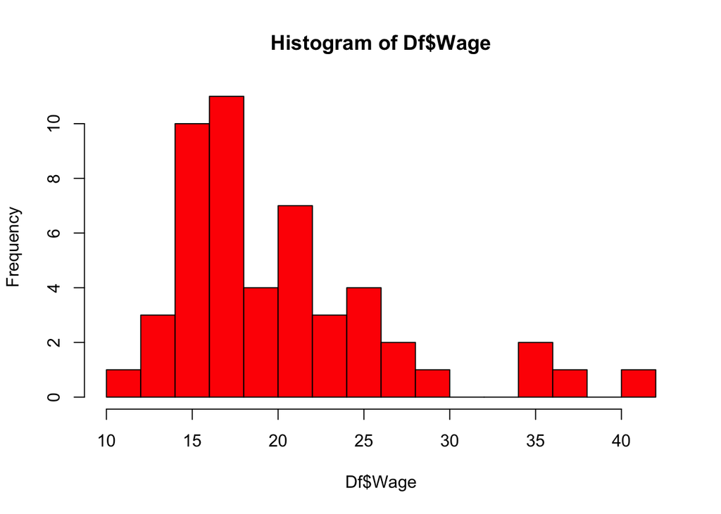

```r
hist(Df$Wage, breaks = 20, col = "red")
```

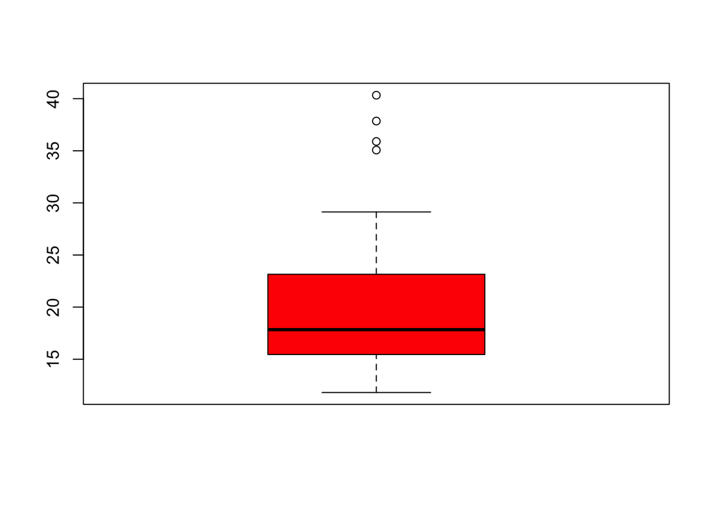

```r
boxplot(Df$Wage, col="red")
```

Perhaps this is due to the presence of outliers in Wage shown by the histogram and boxplot.

```r
library(gvlma)

gvlma(lm1)
```

```
##
## Call:
## lm(formula = Wage ~ Educ + Exper + Age + Male, data = Df)
##
## Coefficients:
## (Intercept)         Educ        Exper          Age         Male
##      8.6848       1.2327       0.4166      -0.0190       2.2897
##
##
## ASSESSMENT OF THE LINEAR MODEL ASSUMPTIONS
## USING THE GLOBAL TEST ON 4 DEGREES-OF-FREEDOM:
## Level of Significance =  0.05
##
## Call:
##  gvlma(x = lm1)
##
##                    Value p-value                Decision
## Global Stat        7.099  0.1307 Assumptions acceptable.
## Skewness           3.574  0.0587 Assumptions acceptable.
## Kurtosis           1.226  0.2681 Assumptions acceptable.
## Link Function      1.009  0.3152 Assumptions acceptable.
## Heteroscedasticity 1.290  0.2560 Assumptions acceptable.
```

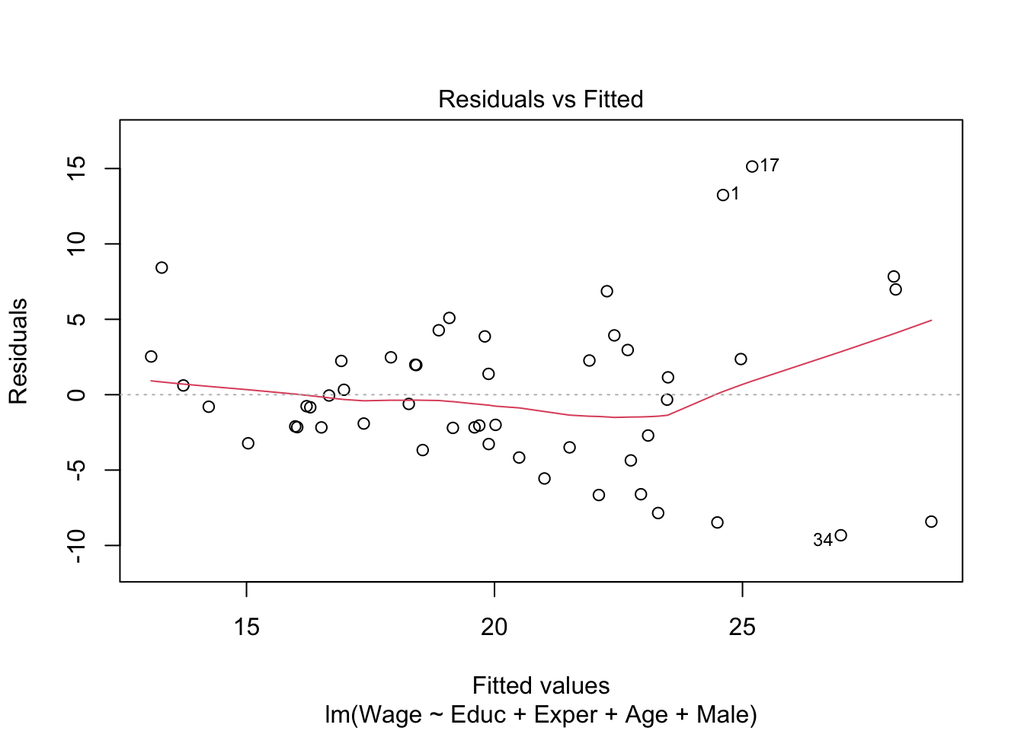

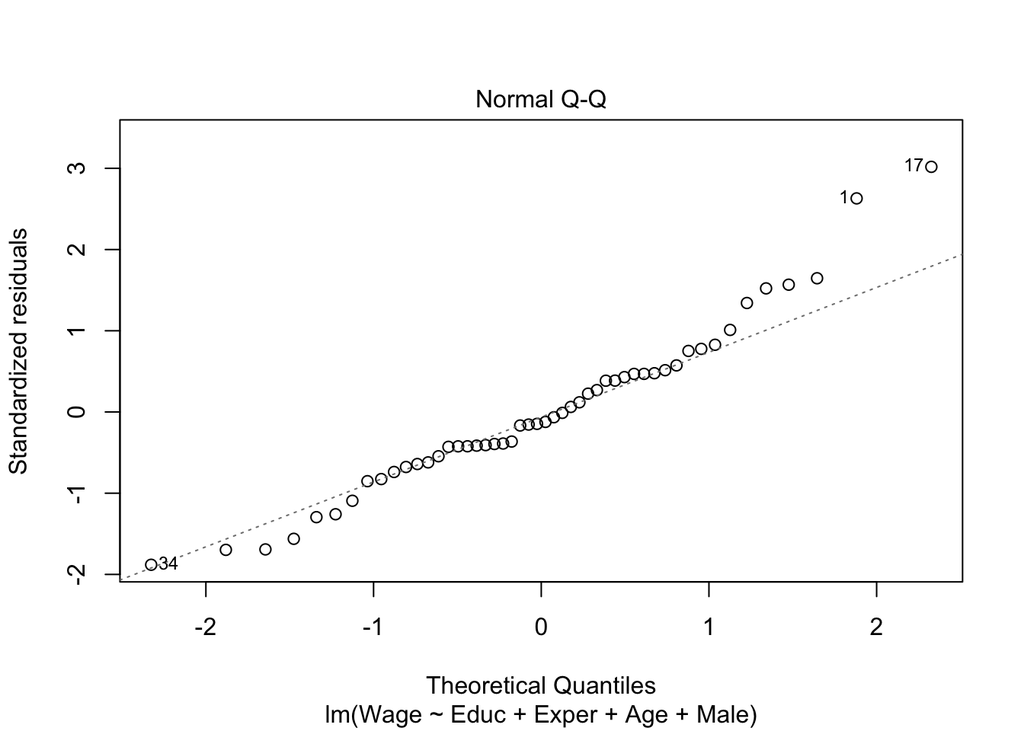

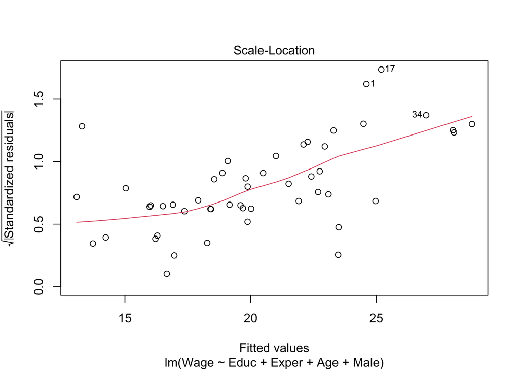

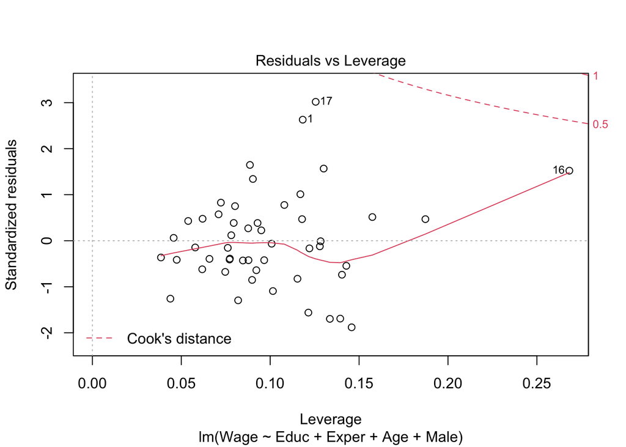

```r
plot(lm1)
```

However, all of the GVLMA assumptions pass, even though the residuals look biased and the QQs show the data has fatter tails.

```r
wage.forty.M<-(8.6847608 + (10 * 1.2327341) + (5 * 0.4165866) + (40 * -0.0190012) + (1 * 2.2896608))
wage.forty.W<-8.6847608 + 10*1.2327341 + 5* 0.4165866 + 40* -0.0190012 + 0* 2.2896608

dif<- round(2.2896608, 2)
```

$\hat{Wage.Forty.Man}=$ 8.6847608 + $10*$ 1.2327341 + $5*$ 0.4165866 + $40*$ -0.0190012 + $1*$ 2.2896608 + $\epsilon$  
$\hat{Wage.Forty.Man}=$ 24.6246476 dollars per hour

$\hat{Wage.Forty.Woman}=$ 8.6847608 + $10*$ 1.2327341 + $5*$ 0.4165866 + $40*$ -0.0190012 + $0*$ 2.2896608 + $\epsilon$  
$\hat{Wage.Forty.Woman}=$ 22.3349868 dollars per hour

The Difference in wages per hour between men and women with the same education and experience is, $2.29 per hour, which is equal to the binary regressor “Male” because when a person is = 1 in “Male”, their wages increase by that amount. However, the independent variable “Male” is not statsitically significant so this relationship is tenuous.

Because the relationships are not staistically clear, this data does not prove any discrimination, but it suggests further investigation would be useful.

```r
lmEd<-lm(data = Df, Wage~Educ)
lmeds<-summary(lmEd)
lmEx<-lm(data = Df, Wage~Exper)
lmexs<-summary(lmEx)
lmAg<-lm(data = Df, Wage~Age)
lmags<-summary(lmAg)
lmMa<-lm(data = Df, Wage~Male)
lmmas<-summary(lmMa)
```

| Variable | Coefficients(intercept, slope) | R squared |
| --- | --- | --- |
| Education | 13.06, 1.154 | 0.177 |
| Experience | 17.55, 0.3050 | 0.0844 |
| Age | 17.48, 0.0647 | 0.0105 |
| Male | 17.97, 4.863 | 0.143 |

## Picking a model

Thus, we see that Education is the best model because it has the highest $R^2$ value of 0.177.

The equation is $\hat{Wage}= \beta_0 + \beta_1Educ$.  
where, $\beta_0=$ 13.06 and $\beta_1=$ 1.154

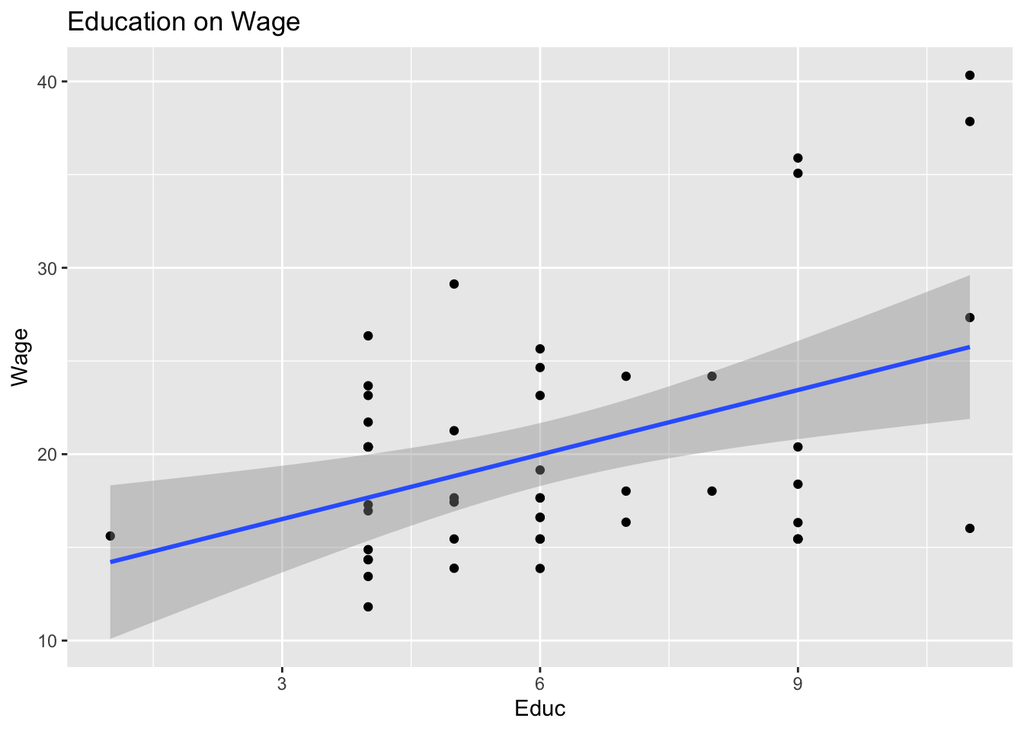

```r
ggplot(Df, aes(Educ, Wage))+
  geom_point()+
  geom_smooth(method= lm)+
  labs(title = "Education on Wage")+
  theme_gray()
```

The scatterplot with the model is showon above. Below, the residual analysis plots are shown.

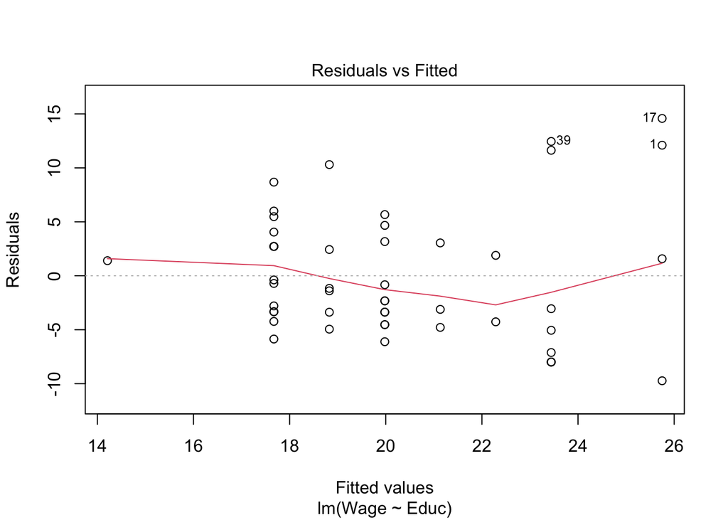

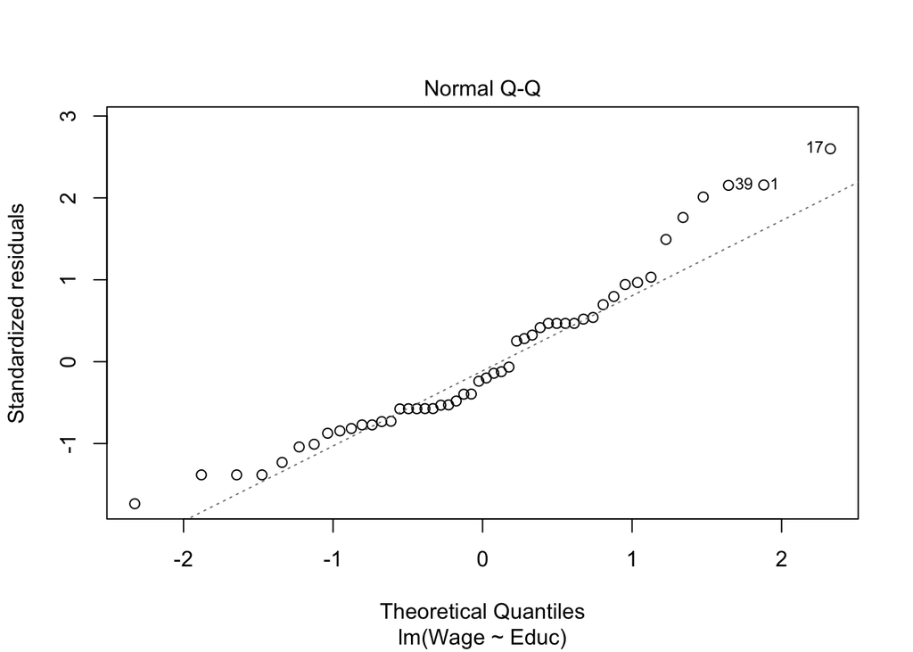

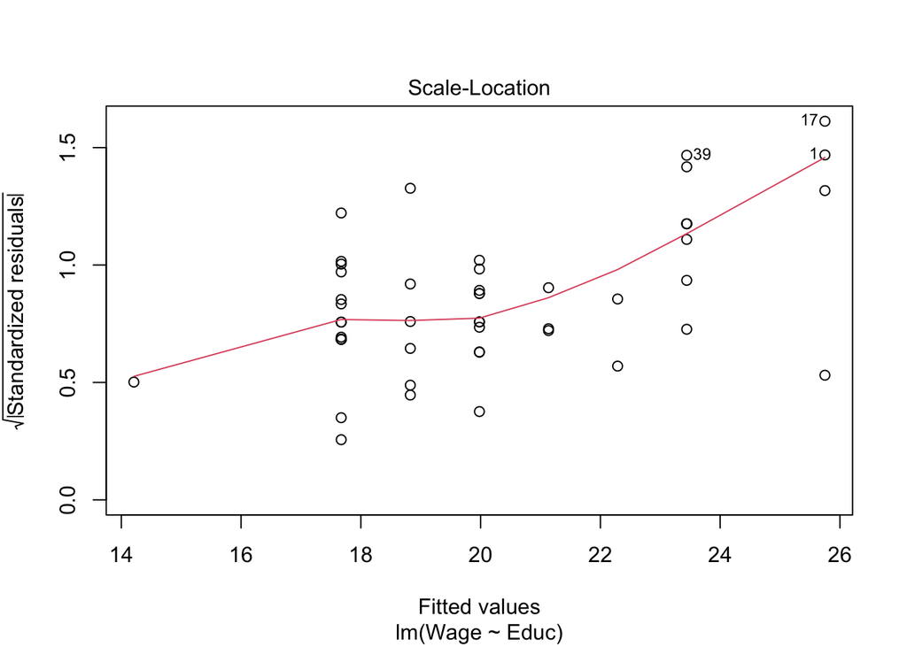

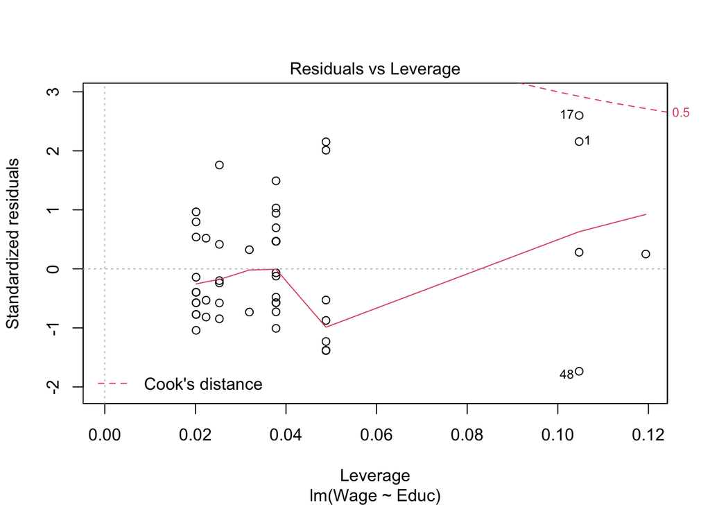

```r
plot(lmEd)
```

## Picking a model for multiple regression

1. $\hat{Wage}= \beta_0 + \beta_1Educ + \beta_2Expert$
2. $\hat{Wage}= \beta_0 + \beta_1Educ + \beta_2Age$
3. $\hat{Wage}= \beta_0 + \beta_1Educ + \beta_2Male$

```r
lmEE<-lm(data = Df, Wage~Educ+Exper)
sEE<-summary(lmEE)
lmEA<-lm(data = Df, Wage~Educ+Age)
sEA<-summary(lmEA)
lmEM<-lm(data = Df, Wage~Educ+Male)
sEM<-summary(lmEM)
```

| Variable | Coefficients(intercept, slope) | Adjusted R squared |
| --- | --- | --- |
| Educ + Exper | 7.46, 1.44, 0.44 | 0.314 |
| Educ + Age | 8.69, 1.20, 0.10 | 0.166 |
| Educ + Male | 13.15, 0.89. 3.33 | 0.202 |

Moroever, this model is better than the model with all the regressors because its $\bar{R^2}$ is higher (0.314 vs 0.312)

## Picking the final model

Now, we will compare the final two models:

1. $\hat{Wage}= \beta_0 + \beta_1Educ + \beta_2Expert+ \beta_3Age$
2. $\hat{Wage}= \beta_0 + \beta_1Educ + \beta_2Expert+ \beta_3Male$

```r
lmEEA<-lm(data = Df, Wage~Educ+Exper+Age)
sEEA<-summary(lmEEA)
lmEEM<-lm(data = Df, Wage~Educ+Exper+Male)
sEEM<-summary
sEEM
```

```
## function (object, ...)
## UseMethod("summary")
## <bytecode: 0x1414363a8>
## <environment: namespace:base>
```

| Variable | Coefficients(intercept, slope) | Adjusted R squared |
| --- | --- | --- |
| Educ + Exper + Age | 7.87, 1.44, 0.45 + -0.01 | 0.299 |
| Educ + Expre + Male | 7.99, 1.24, 0.40 + 2.26 | 0.327 |

The $\best$ model is $\hat{Wage}= \beta_0 + \beta_1Educ + \beta_2Expert+ \beta_3Male$ because it has the highest $\bar{R^2}$ compared to all other multiple rgeression and it is also higher than $R^2$ from single regressions.